# Net Methylmercury Loads from the Yolo Bypass

Dave Bosworth

11/4/2019

# Introduction

We collected water samples from the main inputs and outputs to the Yolo Bypass to calculate mass loads of methylmercury (MeHg) entering and exiting the Bypass during flooding events. We would like to calculate the net loads of MeHg exiting the Bypass for each of our 11 sampling events.

First, we need to bring in the MeHg mass load data.

```r
library(tidyverse)
loads <- read_csv("All_YB_Loads-R.csv")
```

This data contains more data than we need, so I cleaned and filtered the data a bit in order to calculate net loads.

```r
loads <- loads %>%
  select(-c(Conc:Flow)) %>%
  filter(
    Analyte == "MeHg- total",
    LocType != "Below Liberty"
  )
```

This is what the loads dataframe looks like so far:

```
## # A tibble: 6 x 7
##   SamplingEvent   Year StationName       Analyte  LocType    Load LoadUnits
##   <chr>          <dbl> <chr>             <chr>    <chr>     <dbl> <chr>
## 1 Dec 22-23, 20~  2014 CCSB- Overflow W~ MeHg- t~ Inlet   5.64e-1 g/day
## 2 Dec 22-23, 20~  2014 Knights Landing ~ MeHg- t~ Inlet   1.96e+0 g/day
## 3 Dec 22-23, 20~  2014 Putah Creek at M~ MeHg- t~ Inlet   8.33e-3 g/day
## 4 Dec 22-23, 20~  2014 Toe Drain at 1/2~ MeHg- t~ Outlet  6.58e+0 g/day
## 5 Mar 15-16, 20~  2016 CCSB- Overflow W~ MeHg- t~ Inlet   1.07e+0 g/day
## 6 Mar 15-16, 20~  2016 Fremont Weir      MeHg- t~ Inlet   1.65e+1 g/day
```

# Analysis

To calculate net loads, we first need to sum the loads for the inputs and outputs since there are multiple stations for each. The net load is then the difference between the outlet and inlet loads for each sampling event.

```r
netLoads <- loads %>%
  group_by(SamplingEvent, LocType) %>%
  summarize(TotalLoad = sum(Load)) %>%
  ungroup() %>%
  pivot_wider(names_from = LocType, values_from = TotalLoad) %>%
  mutate(NetLoad = Outlet - Inlet)
```

Here are the net loads in grams per day:

```
## # A tibble: 11 x 4
##    SamplingEvent      Inlet Outlet NetLoad
##    <fct>              <dbl>  <dbl>   <dbl>
##  1 Dec 22-23, 2014     2.53   6.58    4.05
##  2 Mar 15-16, 2016    18.1   47.0    28.9
##  3 Jan 11-12, 2017    64.3   82.1    17.8
##  4 Jan 24-25, 2017    23.6   34.0    10.4
##  5 Jan 31-Feb 1, 2017  5.89  11.6     5.75
##  6 Feb 14-15, 2017    52.8   83.1    30.3
##  7 Mar 1-2, 2017      28.8   39.2    10.4
##  8 Mar 15-16, 2017     3.23   6.52    3.29
##  9 Mar 28-29, 2017     7.96  27.4    19.5
## 10 Apr 11-12, 2017     3.14  13.3    10.1
## 11 Apr 25-26, 2017     5.84  22.6    16.8
```

# Results

We would like a quick plot to visualize the net loads of MeHg for each sampling event.

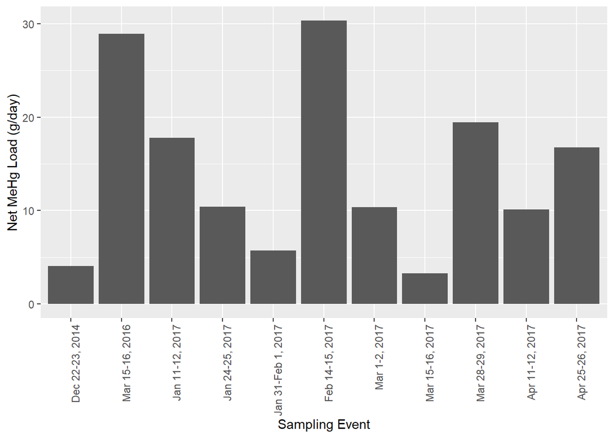

```r
netLoads %>%
  ggplot(
    aes(
      x = SamplingEvent,
      y = NetLoad
    )
  ) +
  geom_col() +
  labs(
    x = "Sampling Event",
    y = "Net MeHg Load (g/day)"
  ) +
  theme(axis.text.x = element_text(angle = 90, hjust = 1))
```

The average net load of MeHg of all 11 sampling events was 14.3 g/day.